# STAT 650 - Final Project

## 4. Results and Interpretation

> **[Guideline]** Presents the findings of the analysis and interpretation of these results. the performance of the models, statistical significance (p-value), Interpret coefficients of significant predictors in your best model, and what these results imply

### [4-1 RH 1 - Pearson Correlation](https://github.com/yoojunT/STAT650_Final_Assignment/blob/main/Section%204-1%20Research%20Hypothesis%201.ipynb)

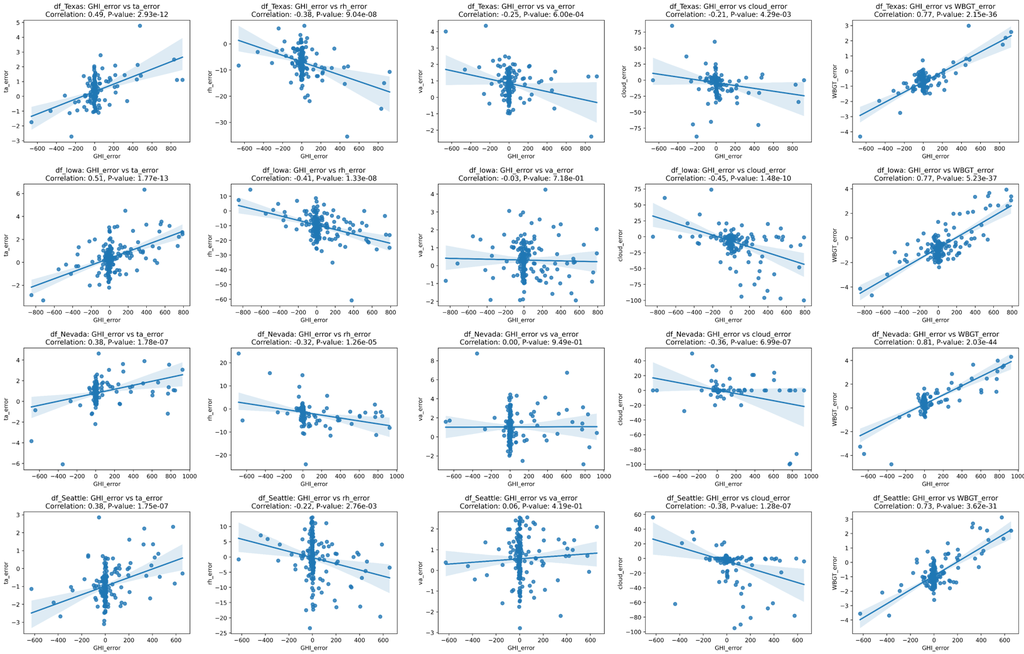

### [4-2 RH 2 - One-way ANOVA test](https://github.com/yoojunT/STAT650_Final_Assignment/blob/main/Section%204-2%20Research%20Hypothesis%202.ipynb)

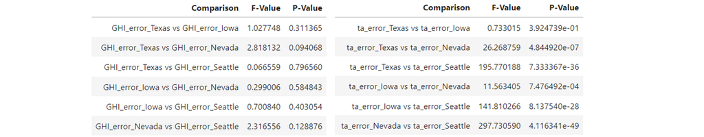

### [4-3 RH 3 - Regression models](https://github.com/yoojunT/STAT650_Final_Assignment/blob/main/Section%204-3%20Research%20Hypothesis%203.ipynb)

This section introduces a comparison between two regression models: a simple regression model that utilizes the independent variable exhibiting the highest correlation with the dependent variable, and a multiple regression model that includes variables surpassing a 0.1 correlation threshold. The effect of modifying these correlation thresholds on model performance is also examined. Additionally, to further improve the model, the results of Lasso and Ridge regression methods, applied with different alpha values, are analyzed and compared.The train and test datasets are randomlay split with 0.7 and 0.3 ratios, respectively. The findings are presented in the tables below.

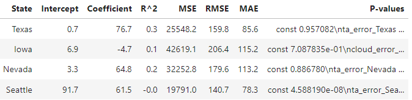

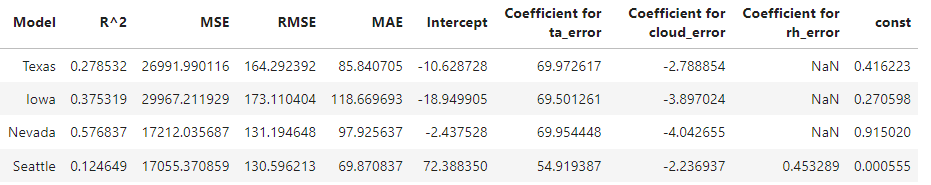

**[Model Improvement Plan 1]** - Different correlation thresholds on multiple regression model The below table details the impact of varying correlation thresholds on a multiple regression model. These thresholds, set between 0 and 1 at intervals of 0.1, continue until no independent variables remain. Despite altering the threshold from the initial 0.1, there is no observed improvement in model performance across all cases. However, it is important to note that these results could differ with alternative datasets. While the current dataset shows no enhancement, this approach may prove effective in other scenarios, particularly where more influential variables are present and issues of multicollinearity are mitigated. This suggests potential applicability in diverse data environments where similar trends are observed.

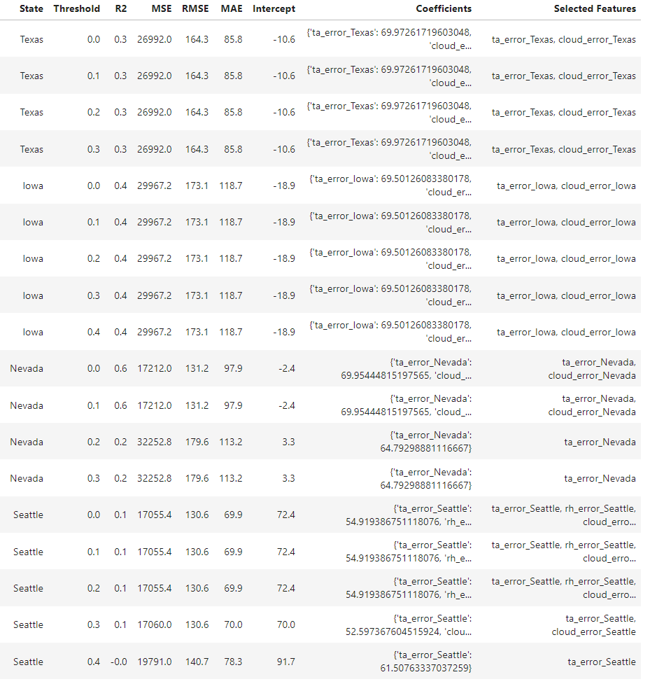

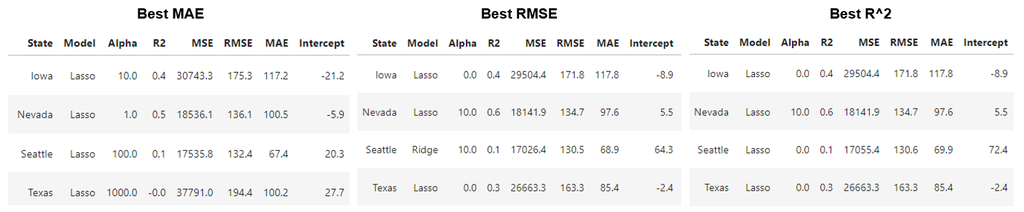

## 5. Conclusion

> **[Guideline]** Summarizes the main discoveries of the project and their implications. Discuss whether the selecteds model met the expectations to conclude each hypothesis, Discuss the limitations of the project, and Suggest the possible directions for future research to overcome the limitation.

#### **Limitations and possible directions for future research**

- The first limitation of this study lies in its temporal and spatial scope. While Section 1-3 provides a well-founded rationale for these boundaries, it is important to acknowledge that expanding the scope in terms of time and space could significantly enrich the study's findings. In particular, the incorporation of a more diverse range of climate regions warrants attention, as evidenced by the varying performances of region-specific regression models highlighted in the results. Addressing this aspect could enhance the scalability and applicability of the project, allowing for a more comprehensive understanding of the models' effectiveness across different environmental contexts. Such expansion would not only validate the current findings but also potentially reveal new insights into the dynamics of climate-related data analysis.
- The second limitation of this project is its exclusive focus on regression models by the project's requirements. This approach may overlook the potential benefits of alternative methodologies. Machine learning techniques, already employed in related research, could offer valuable insights and improvements for this purpose. Additionally, optimization methods like the Kalman filter present another viable alternative. The Kalman filter, in particular, is advantageous for its ability to minimize computational costs and its reduced sensitivity to outliers in the dataset. This is due to its unique mechanism of continuously updating its Kalman gain based on new data. Exploring these diverse approaches could significantly enhance the robustness and efficiency of the models, leading to more accurate and reliable forecasting outcomes.
- The third limitation of this study is the approach to splitting the training and testing datasets, which was done randomly without considering temporal factors. This was a necessary compromise due to project constraints for comparing the performance of regression models. However, since the data is time-series in nature, where more recent historical data often contains richer and more relevant information, this approach might not be ideal. For future enhancements, it is crucial to consider models specifically optimized for time-series analysis. Models such as the Autoregressive Integrated Moving Average (ARIMA) or machine learning algorithms like Long Short-Term Memory (LSTM) networks, which excel in handling data with pronounced temporal dynamics, could be more effective. Moreover, the study did not incorporate post-processing steps, a common practice in forecasting. Implementing these steps and employing time-series optimized models could substantially enhance the effectiveness and precision of heat risk predictions. Such advancements would not only improve predictive accuracy but also offer a more nuanced and comprehensive methodology for assessing heat risks over time.

## 6. Reference and Appendix

> **[Guideline]** Reference: Lists all the sources cited in the report. Appendix: Includes any additional tables, charts, code, or other relevant material, if necessary. Python code: use the following steps to input your code as

### 6-1 Reference

- [Ono, M. & Tonouchi, M. Estimation of wet-bulb globe temperature using generally measured meteorological indices. JAPANESE J. Biometeorol. 50, 147–157 (2014)](https://www.jstage.jst.go.jp/article/seikisho/50/4/50_147/_article/-char/en)
- [High-Resolution Rapid Refresh (HRRR) Website](https://rapidrefresh.noaa.gov/hrrr/)
- [High-Resolution Rapid Refresh (HRRR) Variable Description Webiste](https://mesowest.utah.edu/html/hrrr/zarr_documentation/html/zarr_variables.html).

### 6-2 Appendix

- All the relevant and additional materials uploaded in this Github Repository

### 6-3 Codes

All the codes are linked to the files shared in the Github. This format of code submission was confirmed by the instructor. However, to ensure following the instruction, here I copy and paste all the python codes used in the formats of backticks. For the runnable codes, refer to the Github and hyperlinks for each steps in this report. Below is a list of shared codes:

- [Section 2-1 Data Collection](https://github.com/yoojunT/STAT650_Final_Assignment/blob/main/Section%202-1%20Data%20Collection.ipynb)
- [Section 2-2-1 EDA_RMSE_MAE_Plots](https://github.com/yoojunT/STAT650_Final_Assignment/blob/main/Section%202-2-1%20EDA_RMSE_MAE_Plots.ipynb)
- [Section 2-2-2 EDA_Multicollinearity](https://github.com/yoojunT/STAT650_Final_Assignment/blob/main/Section%202-2-2%20EDA_Multicollinearity.ipynb)
- [Section 4-1 Research Hypothesis 1](https://github.com/yoojunT/STAT650_Final_Assignment/blob/main/Section%204-1%20Research%20Hypothesis%201.ipynb)
- [Section 4-2 Research Hypothesis 2](https://github.com/yoojunT/STAT650_Final_Assignment/blob/main/Section%204-2%20Research%20Hypothesis%202.ipynb)
- [Section 4-3 Research Hypothesis 3](https://github.com/yoojunT/STAT650_Final_Assignment/blob/main/Section%204-3%20Research%20Hypothesis%203.ipynb)

```python
"""
# Section 2-1 Data Collection
from NOMADS_extraction import NOMADS
from datetime import date, timedelta
import xarray as xr
import matplotlib.pyplot as plt

import os
import numpy as np

# Numpy
# Define the start and end dates
start_date = date(2023, 8, 19)
end_date = date(2023, 8, 30)

# Define the base folder path
base_folder_path = './Data/'

# Create directories for each date if they don't exist
current_date = start_date
while current_date <= end_date:
    date_folder = os.path.join(base_folder_path, current_date.strftime('%Y-%m-%d'))
    os.makedirs(date_folder, exist_ok=True)
    current_date += timedelta(days=1)

# Process data for each date
for day in (start_date + timedelta(n) for n in range((end_date - start_date).days + 1)):
    for cycle in range(24):
        cycle_folder = os.path.join(base_folder_path, day.strftime('%Y-%m-%d'), str(cycle))
        os.makedirs(cycle_folder, exist_ok=True)

        for forecast_hour in range(24):
            print(f"{day}-{cycle}-{forecast_hour} is in progress..")
            try:
                url, r, idx = NOMADS.get_NOMADS_url_idx(day, cycle, forecast_hour)

                # Download and process data for each parameter
                for parameter in ["TMP:2 m", "DSWRF", "RH:2 m", "WIND", "TCDC"]:
                    try:
                        data_file = NOMADS.download_data(idx, parameter, url)
                        xarr = xr.open_dataset(data_file, engine='cfgrib', backend_kwargs={'indexpath': ''})

                        # Extract the variable of interest as a NumPy array
                        variable_name = list(xarr.data_vars)[0]
                        numpy_data = xarr[variable_name].values

                        # Save the NumPy array to a file
                        save_path = os.path.join(cycle_folder, f'{day}_{cycle}_{forecast_hour}_{variable_name}.npy')
                        np.save(save_path, numpy_data)
                    except IndexError:
                        print(f"Data not found for {parameter} on {day}, cycle {cycle}, forecast hour {forecast_hour}")

            except Exception as e:
                print(f"An error occurred on {day}, cycle {cycle}, forecast hour {forecast_hour}: {e}")

    print(f"Completed processing for {day}")

# Define the date range and parameters
start_date = date(2023, 6, 1)
end_date = date(2023, 8, 30)
parameters = ["dswrf", "r2", "si10", "t2m", "tcc"]

# Base folder path
base_folder_path = './Data/'

# Define locations and their coordinates
locations = {
    "Texas": (236, 937),
    "Iowa": (662, 1006),
    "Nevada": (490, 372),
    "Seattle": (994, 268)
}

# Iterate over each forecast hour
for forecast_hour in range(7, 9):  # From 0 to 18
    # Collect data in a list for each forecast hour and all locations
    data_lists = {location: [] for location in locations}

    for day in (start_date + timedelta(n) for n in range((end_date - start_date).days + 1)):
        for cycle in range(24):
            for location, (latitude, longitude) in locations.items():
                row = {'Date': day, 'Cycle': cycle}
                cycle_folder = os.path.join(base_folder_path, day.strftime('%Y-%m-%d'), str(cycle))

                for parameter in parameters:
                    csv_path = os.path.join(cycle_folder, f'{day}_{cycle}_{forecast_hour}_{parameter}.npy')
                    print(csv_path)
                    if os.path.exists(csv_path) and os.path.getsize(csv_path) > 0:
                        try:
                            data = np.load(csv_path)
                            row[parameter] = data[latitude, longitude]
                        except ValueError as e:
                            print(f"Error loading file {csv_path}: {e}")
                            # Handle the error - e.g., set a default value or skip
                    else:
                        print(f"File {csv_path} not found or is empty")
                        # Handle the missing or empty file case

                data_lists[location].append(row)

    # Convert the lists of dictionaries to DataFrames for all locations
    dfs = {location: pd.DataFrame(data_list) for location, data_list in data_lists.items()}

    # Save the DataFrames to CSV files for all locations
    for location, df in dfs.items():
        output_file_path = f'./Data/{location}/weather_data_forecast_{forecast_hour}.csv'
        df.to_csv(output_file_path, index=False)
        print(f"DataFrame for forecast hour {forecast_hour} in {location} saved to {output_file_path}")

# Define the base folder path
base_folder_path = './Data/NOAA/2023_Summer/Texas/'

# Create a dictionary to store DataFrames
dfs = {}

for forecast_hour in range(19):
    file_path = os.path.join(base_folder_path, f'weather_data_forecast_{forecast_hour}.csv')

    # Use the f-string to dynamically create DataFrame keys (e.g., 'df_0', 'df_1', etc.)
    df_key = f'df_{forecast_hour}'

    # Read the CSV file and store it in the dictionary
    dfs[df_key] = pd.read_csv(file_path)

# Rearrange columns
for forecast_hour in range(19):
    # Use the f-string to dynamically create DataFrame keys (e.g., 'df_0', 'df_1', etc.)
    df_key = f'df_{forecast_hour}'

    #Forecast column
    dfs[df_key]['forecast'] = forecast_hour

    #Hour column
    dfs[df_key]['hour'] = dfs[df_key]['forecast'] + dfs[df_key]['Cycle']
    # dfs[df_key]['hour'] = dfs[df_key]['Cycle']

    #Datetime column
    dfs[df_key]['Date'] = pd.to_datetime(dfs[df_key]['Date'])
    pd.to_timedelta(dfs[df_key]['hour'], unit='h')
    dfs[df_key]['datetime'] = dfs[df_key]['Date'] + pd.to_timedelta(dfs[df_key]['hour'], unit='h')

    #Drop the columns
    dfs[df_key] = dfs[df_key].drop(['Date', 'Cycle', 'hour'], axis=1)

    #Rename the columns
    dfs[df_key].rename(columns={'dswrf': 'GHI', 'r2': 'rh', 'si10': 'va', 't2m': 'ta', 'tcc': 'cloud'}, inplace=True)

    #Change the order
    new_column_order = ['datetime', 'ta', 'GHI', 'rh', 'va', 'cloud', 'forecast']
    dfs[df_key] = dfs[df_key][new_column_order]
```

```python
# Combinging df based on datetime
df = pd.concat(dfs, axis=0)
df.reset_index(drop=True, inplace=True)

df = df.sort_values(by=['datetime', 'forecast'])
df = df.reset_index(drop=True)

df['ta'] = df['ta'] - 273.15 # to celcius
df.head()

def calculate_wbgt(row):
    ta = row['ta']
    GHI = row['GHI']
    rh = row['rh']
    va = row['va']
    GHI =  GHI/1000

    wbgt = 0.735 * ta + 0.0374 * rh + 0.00292 * ta * rh + 7.619 * GHI - 4.557 * (GHI ** 2) - 0.0572 * va - 4.064

    return wbgt


# Apply the function to create a new 'WBGT' column
df['WBGT'] = df.apply(calculate_wbgt, axis=1)

# Section 2-2-1 EDA_RMSE_MAE_Plots
# Import the necessary libraries

import os
import pandas as pd
import numpy as np
from timezonefinder import TimezoneFinder
import matplotlib.pyplot as plt

# Define a list of states for which datasets will be loaded
state_list = ['Texas', 'Iowa', 'Nevada', 'Seattle']

# Define the base folder path where the datasets are located
base_folder_path = './Data/'

# Create an empty dictionary to store DataFrames
dfs = {}

# Loop through each state and load the corresponding dataset
for state in state_list:
    # Construct the file path for the dataset of the current state
    file_path = os.path.join(base_folder_path, f'{state}_0_18.csv')

    # Define a key for the DataFrame in the dictionary
    df_key = f'df_{state}'

    # Load the dataset into a Pandas DataFrame and store it in the dictionary
    dfs[df_key] = pd.read_csv(file_path)

# List the keys (DataFrame names) stored in the 'dfs' dictionary
loaded_datasets = list(dfs)
print(loaded_datasets)

# Define a dictionary that maps state names to their corresponding latitude and longitude coordinates
locations = {
    'Texas': (30.6095651015, -96.3402969602),
    'Nevada': (36.089758655, -115.1833049303),
    'Iowa': (42.0135891695, -93.6356966723),
    'Seattle': (48.6108182606, -123.1479221551)
}

# Initialize a TimezoneFinder instance to determine timezones based on coordinates
tf = TimezoneFinder()

# Assuming 'dfs' is your dictionary of DataFrames
for df_key in dfs:
    # Extract the state name from the DataFrame key
    state = df_key.split('_')[1]

    # Retrieve the latitude and longitude for the state from the 'locations' dictionary
    latitude, longitude = locations[state]

    # Find the timezone for the given latitude and longitude using the TimezoneFinder
    local_timezone = tf.timezone_at(lat=latitude, lng=longitude)

    # Convert the 'datetime' column in the DataFrame to datetime objects
    dfs[df_key]['datetime'] = pd.to_datetime(dfs[df_key]['datetime'])

    # Set the timezone of the 'datetime' column to UTC
    dfs[df_key]['datetime'] = dfs[df_key]['datetime'].dt.tz_localize('UTC')

    # Convert the 'datetime' column to the local timezone
    dfs[df_key]['datetime'] = dfs[df_key]['datetime'].dt.tz_convert(local_timezone)
    dfs[df_key]['datetime'] = dfs[df_key]['datetime'].dt.tz_localize(None)

# Function to calculate Mean Absolute Error (MAE) for specific hours in a DataFrame
def calculate_mae_for_specific_hours(df, specific_hours):
    # Extract the hour component from the 'datetime' column
    df['datetime'] = pd.to_datetime(df['datetime'])
    df['hour'] = df['datetime'].dt.hour

    # Filter the ground truth data (forecast value equals 0)
    ground_truth_data = df[df['forecast'] == 0]

    # Initialize an empty list to hold the MAE data
    mae_data = []

    # Loop over the specific hours for MAE calculation
    for hour in specific_hours:
        # Filter the ground truth data for the specific hour
        ground_truth_hourly = ground_truth_data[ground_truth_data['hour'] == hour]

        for forecast_value in range(1, 19):
            # Filter the forecast data for the specific hour and forecast value
            forecast_data_hourly = df[(df['forecast'] == forecast_value) & (df['hour'] == hour)]
            if not forecast_data_hourly.empty:
                # Merge the ground truth and forecast data based on 'datetime'
                merged_data = pd.merge(ground_truth_hourly, forecast_data_hourly, on='datetime', suffixes=('_ground_truth', f'_forecast_{forecast_value}'))

                # Calculate MAE for each column (e.g., temperature, GHI, humidity, etc.)
                mae_row = {'hour': hour, 'forecast_hour': forecast_value}
                for col in ['ta', 'GHI', 'rh', 'va', 'WBGT']:
                    col_diff = abs(merged_data[col + '_forecast_' + str(forecast_value)] - merged_data[col + '_ground_truth'])
                    mae = col_diff.mean()
                    mae_row[f'{col}_MAE'] = mae

                mae_data.append(mae_row)

    # Convert the list of dictionaries to a DataFrame
    mae_df = pd.DataFrame(mae_data)

    return mae_df

# List of specific hours for MAE calculation
specific_hours = [9, 12, 15, 18]

# Apply the 'calculate_mae_for_specific_hours' function to each DataFrame in 'dfs'
mae_results = {df_key: calculate_mae_for_specific_hours(dfs[df_key], specific_hours) for df_key in dfs}

# Display or process the MAE results for each DataFrame
for key, mae_df in mae_results.items():
    print(f"MAE for {key}:")
    print(mae_df)

# Function to calculate Root Mean Square Error (RMSE) for specific hours in a DataFrame
def calculate_rmse_for_specific_hours(df, specific_hours):
    # Extract the hour component from the 'datetime' column
    df['datetime'] = pd.to_datetime(df['datetime'])
    df['hour'] = df['datetime'].dt.hour

    # Filter the ground truth data (forecast value equals 0)
    ground_truth_data = df[df['forecast'] == 0]

    # Initialize an empty list to hold the RMSE data
    rmse_data = []

    # Loop over the specific hours for RMSE calculation
    for hour in specific_hours:
        # Filter the ground truth data for the specific hour
        ground_truth_hourly = ground_truth_data[ground_truth_data['hour'] == hour]

        for forecast_value in range(1, 19):
            # Filter the forecast data for the specific hour and forecast value
            forecast_data_hourly = df[(df['forecast'] == forecast_value) & (df['hour'] == hour)]
            if not forecast_data_hourly.empty:
                # Merge the ground truth and forecast data based on 'datetime'
                merged_data = pd.merge(ground_truth_hourly, forecast_data_hourly, on='datetime', suffixes=('_ground_truth', f'_forecast_{forecast_value}'))
```

```python
                # Calculate RMSE for each column (e.g., temperature, GHI, humidity, etc.)
                rmse_row = {'hour': hour, 'forecast_hour': forecast_value}
                for col in ['ta', 'GHI', 'rh', 'va', 'WBGT']:
                    col_diff = (merged_data[col + '_forecast_' + str(forecast_value)] - merged_data[col + '_ground_truth']) ** 2
                    rmse = np.sqrt(col_diff.mean())
                    rmse_row[f'{col}_RMSE'] = rmse

                rmse_data.append(rmse_row)

    # Convert the list of dictionaries to a DataFrame
    rmse_df = pd.DataFrame(rmse_data)

    return rmse_df

# List of specific hours for RMSE calculation
specific_hours = [9, 12, 15, 18]

# Apply the 'calculate_rmse_for_specific_hours' function to each DataFrame in 'dfs'
rmse_results = {df_key: calculate_rmse_for_specific_hours(dfs[df_key], specific_hours) for df_key in dfs}

# Display or process the RMSE results for each DataFrame
for key, rmse_df in rmse_results.items():
    print(f"RMSE for {key}:")
    print(rmse_df)

# Define the base folder path where the result files will be saved
base_folder_path = './Result/'

# List of DataFrame names to be processed
df_list = ['df_Texas', 'df_Iowa', 'df_Nevada', 'df_Seattle']

# Loop through each DataFrame name
for df_name in df_list:
    # Retrieve MAE and RMSE results for the current DataFrame
    df1 = mae_results[df_name]
    df2 = rmse_results[df_name]

    # Create a new DataFrame to combine columns
    combined_df = pd.DataFrame({
        'hour': df1['hour'],
        'forecast_hour': df1['forecast_hour'],
    })

    # Combine columns for different parameters (e.g., temperature, GHI, humidity, etc.)
    for param in ['ta', 'GHI', 'rh', 'va', 'WBGT']:
        mae_col_name = f'{param}_MAE'
        rmse_col_name = f'{param}_RMSE'

        # Add RMSE and MAE columns for the current parameter to the combined DataFrame
        combined_df[f'{param} (RMSE)'] = df2[rmse_col_name]
        combined_df[f'{param} (MAE)'] = df1[mae_col_name]

    # Define the file path for saving the combined DataFrame as a CSV file
    file_path = os.path.join(base_folder_path, f'{df_name}_RMSE_MAE.csv')

    # Save the combined DataFrame to a CSV file
    combined_df.to_csv(file_path, index=False)

    # Print a message indicating that the combined DataFrame has been successfully saved
    print(f"Combined DataFrame for {df_name} saved as {df_name}_RMSE_MAE.csv")

# Define the base folder path where the result files are located
base_folder_path = './Result/'

# List of DataFrame names (states) to be loaded
state_list = ['df_Texas', 'df_Iowa', 'df_Nevada', 'df_Seattle']

# Create an empty dictionary to store the loaded DataFrames
dfs = {}

# Loop through each DataFrame name (state) in the list
for state in state_list:
    # Construct the file path for the RMSE and MSE CSV file of the current state
    file_path = os.path.join(base_folder_path, f'{state}_RMSE_MSE.csv')

    # Define a key for the DataFrame in the dictionary
    df_key = f'{state}'

    # Load the CSV file into a Pandas DataFrame and store it in the dictionary
    dfs[df_key] = pd.read_csv(file_path)

# List the keys (DataFrame names) stored in the 'dfs' dictionary
loaded_states = list(dfs)

# List of DataFrame names (states) in a list
dfs_names = ['df_Texas', 'df_Iowa', 'df_Nevada', 'df_Seattle']

# Define a color for each state
state_colors = {
    'df_Texas': 'blue',
    'df_Iowa': 'green',
    'df_Nevada': 'red',
    'df_Seattle': 'purple'
}

# State abbreviations
state_abbreviations = {
    'df_Texas': 'Texas',
    'df_Iowa': 'Iowa',
    'df_Nevada': 'Nevada',
    'df_Seattle': 'Seattle'
}

# Create subplots with a 5x4 grid layout
fig, axes = plt.subplots(nrows=5, ncols=4, figsize=(15, 16))

# Adjust the spacing between subplots
plt.subplots_adjust(hspace=0.2, wspace=0.8)

# List of specific hours for plotting
hours = [9, 12, 15, 18]

# LaTeX formatted variable names for plot labels
variables = [r"${T}_{a}$", 'GHI', r"RH", r"${V}_{a}$", 'WBGT']

# Units for each variable
units = {r"${T}_{a}$": '°C', 'GHI': 'W/m²', r"RH": '%', r"${V}_{a}$": 'm/s', 'WBGT': '°C'}

# Mapping from LaTeX formatted variable names to DataFrame column names
variable_column_mapping = {
    r"${T}_{a}$": 'ta (RMSE)',
    'GHI': 'GHI (RMSE)',
    r"RH": 'rh (RMSE)',
    r"${V}_{a}$": 'va (RMSE)',
    'WBGT': 'WBGT (RMSE)'
}

# Calculate maximum values for each variable across all DataFrames
max_values = {}
for var in variables:
    column_name = variable_column_mapping[var]
    max_values[var] = max(df[column_name].max() for df in dfs.values()) * 1.1

# Create empty lists to store legend handles and labels
handles_list = []

# Iterate over variables and specific hours for plotting
for j, var in enumerate(variables):
    for i, hour in enumerate(hours):
        ax = axes[j, i]  # Access the subplot

        # Turn off grid lines for the current subplot
        ax.grid(False)

        # Plot data for each state with smaller markers 'o'
        for df_name in dfs_names:
            df = dfs[df_name]  # Access the dataframe using its name
            filtered_df = df[df['hour'] == hour]

            # Retrieve the correct column name using the mapping
            column_name = variable_column_mapping[var]

            # Plot data and add it to the legend handles list
            line, = ax.plot(filtered_df['forecast_hour'], filtered_df[column_name],
                            label=state_abbreviations[df_name], color=state_colors[df_name], marker='o', markersize=4)

            # Add the handle for the legend if not already added
            if state_abbreviations[df_name] not in [h.get_label() for h in handles_list]:
                handles_list.append(line)

        # Set the y-axis limits
        ax.set_ylim(0, max_values[var])

        # Set x and y-axis labels for all subplots
        ax.set_xlabel(f'Forecast Hour at {hour}:00', fontsize=12)
        ax.set_ylabel(f'{var} ({units[var]}) - RMSE', fontsize=12)
        ax.tick_params(axis='y', labelsize=11)
```

```python
        # Set the fontsize for x-axis tick labels
        ax.set_xticks(range(0, 19, 2))
        ax.tick_params(axis='x', labelsize=11)

# Create a single legend below the subplots at the center
fig.legend(handles_list, [h.get_label() for h in handles_list], loc='lower center', bbox_to_anchor=(0.83, -0.025), ncol=4, fontsize=12)

# Adjust the layout so the legend does not overlap with subplots
plt.tight_layout()

# Save the figure as a PNG file with high DPI
plt.savefig('./Result/RMSE_per_State_Variable_Hour.png', dpi=500, transparent=True, bbox_inches='tight')

# Display the plot
plt.show()

# List of DataFrame names (states) in a list
dfs_names = ['df_Texas', 'df_Iowa', 'df_Nevada', 'df_Seattle']

# Define a color for each state
state_colors = {
    'df_Texas': 'blue',
    'df_Iowa': 'green',
    'df_Nevada': 'red',
    'df_Seattle': 'purple'
}

# State abbreviations for labeling
state_abbreviations = {
    'df_Texas': 'Texas',
    'df_Iowa': 'Iowa',
    'df_Nevada': 'Nevada',
    'df_Seattle': 'Seattle'
}

# Create subplots with a 5x4 grid layout and specified figure size
fig, axes = plt.subplots(nrows=5, ncols=4, figsize=(15, 16))

# Adjust the spacing between subplots
plt.subplots_adjust(hspace=0.2, wspace=0.8)

# List of specific hours for plotting
hours = [9, 12, 15, 18]

# LaTeX formatted variable names for plot labels
variables = [r"${T}_{a}$", 'GHI', r"RH", r"${V}_{a}$", 'WBGT']

# Units for each variable
units = {r"${T}_{a}$": '°C', 'GHI': 'W/m²', r"RH": '%', r"${V}_{a}$": 'm/s', 'WBGT': '°C'}

# Mapping from LaTeX formatted variable names to DataFrame column names
variable_column_mapping = {
    r"${T}_{a}$": 'ta (MAE)',
    'GHI': 'GHI (MAE)',
    r"RH": 'rh (MAE)',
    r"${V}_{a}$": 'va (MAE)',
    'WBGT': 'WBGT (MAE)'
}

# Calculate maximum values for each variable across all DataFrames
max_values = {}
for var in variables:
    column_name = variable_column_mapping[var]
    max_values[var] = max(df[column_name].max() for df in dfs.values()) * 1.1

# Create empty lists to store legend handles and labels
handles_list = []

# Iterate over variables and specific hours for plotting
for j, var in enumerate(variables):
    for i, hour in enumerate(hours):
        ax = axes[j, i]  # Access the subplot

        # Turn off grid lines for the current subplot
        ax.grid(False)

        # Plot data for each state with smaller markers 'o'
        for df_name in dfs_names:
            df = dfs[df_name]  # Access the dataframe using its name
            filtered_df = df[df['hour'] == hour]

            # Retrieve the correct column name using the mapping
            column_name = variable_column_mapping[var]

            # Plot data and add it to the legend handles list
            line, = ax.plot(filtered_df['forecast_hour'], filtered_df[column_name],
                            label=state_abbreviations[df_name], color=state_colors[df_name], marker='o', markersize=4)

            # Add the handle for the legend if not already added
            if state_abbreviations[df_name] not in [h.get_label() for h in handles_list]:
                handles_list.append(line)

        # Set the y-axis limits
        ax.set_ylim(0, max_values[var])

        # Set x and y-axis labels for all subplots
        ax.set_xlabel(f'Forecast Hour at {hour}:00', fontsize=12)
        ax.set_ylabel(f'{var} ({units[var]}) - MAE', fontsize=12)
        ax.tick_params(axis='y', labelsize=11)

        # Set the fontsize for x-axis tick labels
        ax.set_xticks(range(0, 19, 2))
        ax.tick_params(axis='x', labelsize=11)

# Create a single legend below the subplots at the center
fig.legend(handles_list, [h.get_label() for h in handles_list], loc='lower center', bbox_to_anchor=(0.83, -0.025), ncol=4, fontsize=12)

# Adjust the layout so the legend does not overlap with subplots
plt.tight_layout()

# Save the figure as a PNG file with high DPI
plt.savefig('./Result/MAE_per_State_Variable_Hour.png', dpi=500, transparent=True, bbox_inches='tight')

# Display the plot
plt.show()

# Section 2-2-2 EDA_Multicollinearity

# Import the necessary libraries
import os
import pandas as pd
import numpy as np
from timezonefinder import TimezoneFinder
import matplotlib.pyplot as plt

import statsmodels.api as sm
from statsmodels.stats.outliers_influence import variance_inflation_factor

# Define a list of states for which datasets will be loaded
state_list = ['Texas', 'Iowa', 'Nevada', 'Seattle']

# Define the base folder path where the datasets are located
base_folder_path = './Data/'

# Create an empty dictionary to store DataFrames
dfs = {}

# Loop through each state and load the corresponding dataset
for state in state_list:
    # Construct the file path for the dataset of the current state
    file_path = os.path.join(base_folder_path, f'{state}_0_18.csv')

    # Define a key for the DataFrame in the dictionary
    df_key = f'df_{state}'

    # Load the dataset into a Pandas DataFrame and store it in the dictionary
    dfs[df_key] = pd.read_csv(file_path)

# List the keys (DataFrame names) stored in the 'dfs' dictionary
loaded_datasets = list(dfs)
print(loaded_datasets)

# Define a dictionary that maps state names to their corresponding latitude and longitude coordinates
locations = {
    'Texas': (30.6095651015, -96.3402969602),
    'Nevada': (36.089758655, -115.1833049303),
    'Iowa': (42.0135891695, -93.6356966723),
    'Seattle': (48.6108182606, -123.1479221551)
}

# Initialize a TimezoneFinder instance to determine timezones based on coordinates
tf = TimezoneFinder()

# Assuming 'dfs' is your dictionary of DataFrames
for df_key in dfs:
    # Extract the state name from the DataFrame key
    state = df_key.split('_')[1]

    # Retrieve the latitude and longitude for the state from the 'locations' dictionary
    latitude, longitude = locations[state]

    # Find the timezone for the given latitude and longitude using the TimezoneFinder
    local_timezone = tf.timezone_at(lat=latitude, lng=longitude)

    # Convert the 'datetime' column in the DataFrame to datetime objects
    dfs[df_key]['datetime'] = pd.to_datetime(dfs[df_key]['datetime'])
```

```python
    # Set the timezone of the 'datetime' column to UTC
    dfs[df_key]['datetime'] = dfs[df_key]['datetime'].dt.tz_localize('UTC')

    # Convert the 'datetime' column to the local timezone
    dfs[df_key]['datetime'] = dfs[df_key]['datetime'].dt.tz_convert(local_timezone)
    dfs[df_key]['datetime'] = dfs[df_key]['datetime'].dt.tz_localize(None)

# Iterate through each DataFrame in the dictionary
for df_key in dfs:
    # Convert the 'datetime' column to pandas datetime format
    dfs[df_key]['datetime'] = pd.to_datetime(dfs[df_key]['datetime'])

    # Define the desired times for filtering
    desired_times = ['12:00:00', '15:00:00']

    # Filter the DataFrame for hours between 12:00:00 and 15:00:00
    dfs[df_key] = dfs[df_key][dfs[df_key]['datetime'].dt.strftime('%H:%M:%S').isin(desired_times)]

    # Define the desired forecast values for filtering
    desired_forecasts = [0, 3]

    # Extract rows where forecast is either 0 or 3
    dfs[df_key] = dfs[df_key][dfs[df_key]['forecast'].isin(desired_forecasts)]

    # Reset the index of the filtered DataFrame
    dfs[df_key] = dfs[df_key].reset_index(drop=True)

# Iterate through each DataFrame in the dictionary
for df_key in dfs:
    # Convert the 'datetime' column to pandas datetime format
    dfs[df_key]['datetime'] = pd.to_datetime(dfs[df_key]['datetime'])

    # Define the desired times for filtering
    desired_times = ['12:00:00', '15:00:00']

    # Filter the DataFrame for hours between 12:00:00 and 15:00:00
    dfs[df_key] = dfs[df_key][dfs[df_key]['datetime'].dt.strftime('%H:%M:%S').isin(desired_times)]

    # Define the desired forecast values for filtering
    desired_forecasts = [0, 3]

    # Extract rows where forecast is either 0 or 3
    dfs[df_key] = dfs[df_key][dfs[df_key]['forecast'].isin(desired_forecasts)]

    # Reset the index of the filtered DataFrame
    dfs[df_key] = dfs[df_key].reset_index(drop=True)


# Iterate through each DataFrame in the dictionary
for df_key in dfs:
    # Convert the 'datetime' column to pandas datetime format
    dfs[df_key]['datetime'] = pd.to_datetime(dfs[df_key]['datetime'])

    # Filter to get the rows where forecast == 0
    reference_df = dfs[df_key][dfs[df_key]['forecast'] == 0]

    # Merge the original DataFrame with the reference DataFrame
    merged_df = dfs[df_key].merge(reference_df[['datetime', 'ta', 'GHI', 'rh', 'va', 'cloud', 'WBGT']], on='datetime', suffixes=('', '_ref'))

    # Calculate the forecast error for each column
    merged_df['ta_error'] = merged_df['ta'] - merged_df['ta_ref']
    merged_df['GHI_error'] = merged_df['GHI'] - merged_df['GHI_ref']
    merged_df['rh_error'] = merged_df['rh'] - merged_df['rh_ref']
    merged_df['va_error'] = merged_df['va'] - merged_df['va_ref']
    merged_df['cloud_error'] = merged_df['cloud'] - merged_df['cloud_ref']
    merged_df['WBGT_error'] = merged_df['WBGT'] - merged_df['WBGT_ref']

    # Save the merged DataFrame back into the dictionary
    dfs[df_key] = merged_df

#Rename each columns

df_T = dfs['df_Texas'][['datetime', 'GHI_error', 'cloud_error', 'forecast']]
df_T = df_T.rename(columns={'GHI_error': 'GHI_error_Texas', 'cloud_error': 'cloud_error_Texas'})

df_I = dfs['df_Iowa'][['datetime', 'GHI_error', 'cloud_error', 'forecast']]
df_I = df_I.rename(columns={'GHI_error': 'GHI_error_Iowa', 'cloud_error': 'cloud_error_Iowa'})

df_N = dfs['df_Nevada'][['datetime', 'GHI_error', 'cloud_error', 'forecast']]
df_N = df_N.rename(columns={'GHI_error': 'GHI_error_Nevada', 'cloud_error': 'cloud_error_Nevada'})

df_S = dfs['df_Seattle'][['datetime', 'GHI_error', 'cloud_error', 'forecast']]
df_S = df_S.rename(columns={'GHI_error': 'GHI_error_Seattle', 'cloud_error': 'cloud_error_Seattle'})

# Custom suffixes can be provided to avoid column name conflicts
custom_suffixes = ('_dfT', '_dfI')  # You can choose appropriate suffixes

# Merging df_T and df_I with custom suffixes, on both 'datetime' and 'forecast'
combined_df = pd.merge(df_T, df_I, on=['datetime', 'forecast'], how='inner', suffixes=custom_suffixes)

# Merging with df_N and df_S
# Note: You may need to adjust suffixes again if there are still conflicts
combined_df = pd.merge(combined_df, df_N, on=['datetime', 'forecast'], how='inner')
combined_df = pd.merge(combined_df, df_S, on=['datetime', 'forecast'], how='inner')

combined_df.head()

#only 3-hour forecast
for df_key in dfs:
    dfs[df_key] = dfs[df_key].loc[dfs[df_key]['forecast'] == 3]

    # Reset the index
    dfs[df_key] = dfs[df_key].reset_index(drop=True)

# only for errors
for df_key in dfs:
    error_columns = dfs[df_key].filter(like='_error').columns
    dfs[df_key] = dfs[df_key][error_columns]

import pandas as pd
import statsmodels.api as sm
from statsmodels.stats.outliers_influence import variance_inflation_factor

# Assuming dfs is your dictionary of DataFrames for each state
vif_data_per_state = {}

for df_key, df in dfs.items():
    # Adding a constant term for intercept
    df_with_const = sm.add_constant(df)

    # Initialize DataFrame to store VIF for each variable
    vif_data = pd.DataFrame()
    vif_data['Variable'] = df_with_const.columns

    # Calculate VIF for each variable
    vif_data['VIF'] = [variance_inflation_factor(df_with_const.values, i) for i in range(df_with_const.shape[1])]

    # Store the VIF data in the dictionary with state name as the key
    vif_data_per_state[df_key] = vif_data

    # Optionally print each state's VIF data
    print(f'VIF Data for {df_key}:')
    print(vif_data)

# Section 4-1 Research Hypothesis 1
# Pearson Correlation

# Make a copy of the combined dataframe for analysis
df = combined_df.copy()

# Define a list of states to analyze
states = ['Texas', 'Iowa', 'Nevada', 'Seattle']

# Calculate the Pearson Correlation between GHI (Global Horizontal Irradiance) error
# and cloud error for each state in the list
for state in states:
    ghi_error = f'GHI_error_{state}'  # Column name for GHI error specific to the state
    cloud_error = f'cloud_error_{state}'  # Column name for cloud error specific to the state
```

```python
    # Compute the Pearson Correlation coefficient and p-value for the two variables
    correlation, p_value = stats.pearsonr(df[ghi_error], df[cloud_error])

    # Print the Pearson Correlation and p-value for the current state
    print(f'Pearson Correlation for {state}: {correlation}, P-value: {p_value}')

# Get the total number of DataFrames in the 'dfs' dictionary
num_rows = len(dfs)

# Calculate the maximum number of columns among the DataFrames, excluding 'GHI_error'
num_cols = max(len(df.columns) - 1 for df in dfs.values())  # Subtract 1 to exclude 'GHI_error'

# Create a figure with subplots based on the number of rows and columns
fig, axes = plt.subplots(num_rows, num_cols, figsize=(num_cols * 5, num_rows * 4))  # Adjust the figure size as needed

# Iterate over each DataFrame and each column in the DataFrames
for i, (df_key, df) in enumerate(dfs.items()):
    if 'GHI_error' in df.columns:
        # Iterate over columns in the DataFrame excluding 'GHI_error'
        for j, column in enumerate([col for col in df.columns if col != 'GHI_error']):
            # Calculate the Pearson correlation coefficient and p-value
            correlation, p_value = stats.pearsonr(df['GHI_error'], df[column])

            # Create a scatter plot with a regression line in the appropriate subplot
            sns.regplot(x='GHI_error', y=column, data=df, ax=axes[i, j])

            # Set the subplot title with the correlation value and p-value
            axes[i, j].set_title(f'{df_key}: GHI_error vs {column}\nCorrelation: {correlation:.2f}, P-value: {p_value:.2e}')
    else:
        # Print a message if 'GHI_error' is not found in the DataFrame
        print(f"'GHI_error' not found in {df_key}")

# Adjust the layout of subplots for better visualization
plt.tight_layout()

# Save the resulting figure as an image with high DPI, transparency, and tight bounding box
plt.savefig('./Result/RH1_Correlation.png', dpi=500, transparent=True, bbox_inches='tight')

# Display the figure
plt.show()


# Section 4-2 Research Hypothesis 2
import pandas as pd
from scipy import stats

# List of GHI_error columns for each state
ghi_columns = ['GHI_error_Texas', 'GHI_error_Iowa', 'GHI_error_Nevada', 'GHI_error_Seattle']

# List to store results
results_list = []

# Perform ANOVA for each pair of GHI_error columns
for i in range(len(ghi_columns)):
    for j in range(i+1, len(ghi_columns)):
        # Extract data for the two columns
        data_i = combined_df[ghi_columns[i]]
        data_j = combined_df[ghi_columns[j]]

        # Perform ANOVA
        f_value, p_value = stats.f_oneway(data_i, data_j)

        # Append the results to the list
        results_list.append({
            'Comparison': f'{ghi_columns[i]} vs {ghi_columns[j]}',
            'F-Value': f_value,
            'P-Value': p_value
        })

# Convert the list of dictionaries to a DataFrame
results_df = pd.DataFrame(results_list)

# Output the DataFrame
results_df

# List of ta_error columns for each state
ta_columns = ['ta_error_Texas', 'ta_error_Iowa', 'ta_error_Nevada', 'ta_error_Seattle']

# List to store results
results_list = []

# Perform ANOVA for each pair of GHI_error columns
for i in range(len(ta_columns)):
    for j in range(i+1, len(ta_columns)):
        # Extract data for the two columns
        data_i = combined_df[ta_columns[i]]
        data_j = combined_df[ta_columns[j]]

        # Perform ANOVA
        f_value, p_value = stats.f_oneway(data_i, data_j)

        # Append the results to the list
        results_list.append({
            'Comparison': f'{ta_columns[i]} vs {ta_columns[j]}',
            'F-Value': f_value,
            'P-Value': p_value
        })

# Convert the list of dictionaries to a DataFrame
results_df = pd.DataFrame(results_list)

# Output the DataFrame
results_df

# List of cloud_error columns for each state
cloud_columns = ['cloud_error_Texas', 'cloud_error_Iowa', 'cloud_error_Nevada', 'cloud_error_Seattle']

# Dictionary to store results
results = {}

# Perform ANOVA for each pair of cloud_error columns
for i in range(len(cloud_columns)):
    for j in range(i+1, len(cloud_columns)):
        # Extract data for the two columns
        data_i = combined_df[cloud_columns[i]]
        data_j = combined_df[cloud_columns[j]]

        # Perform ANOVA
        f_value, p_value = stats.f_oneway(data_i, data_j)

        # Store the results
        result_key = f'{cloud_columns[i]} vs {cloud_columns[j]}'
        results[result_key] = {'F-Value': f_value, 'P-Value': p_value}

# Output the results for each comparison
for comparison, result in results.items():
    print(f'Comparison: {comparison}')
    print('F-Value:', result['F-Value'])
    print('P-Value:', result['P-Value'])
    print()

# Section 4-3 Research Hypothesis 3

# Import the necessary libraries
import os
import pandas as pd
import numpy as np
from timezonefinder import TimezoneFinder
import matplotlib.pyplot as plt

import statsmodels.api as sm

from sklearn.model_selection import train_test_split
from sklearn.linear_model import LinearRegression, Lasso, Ridge
from sklearn.metrics import r2_score, mean_squared_error, mean_absolute_error


# For Texas
X_Texas = combined_df[['ta_error_Texas', 'rh_error_Texas', 'cloud_error_Texas']]
y_Texas = combined_df['GHI_error_Texas']
X_train_Texas, X_test_Texas, y_train_Texas, y_test_Texas = train_test_split(X_Texas, y_Texas, test_size=0.3, random_state=42)

# For Iowa
X_Iowa = combined_df[['ta_error_Iowa', 'rh_error_Iowa', 'cloud_error_Iowa']]
y_Iowa = combined_df['GHI_error_Iowa']
X_train_Iowa, X_test_Iowa, y_train_Iowa, y_test_Iowa = train_test_split(X_Iowa, y_Iowa, test_size=0.3, random_state=42)

# For Nevada
X_Nevada = combined_df[['ta_error_Nevada', 'rh_error_Nevada', 'cloud_error_Nevada']]
y_Nevada = combined_df['GHI_error_Nevada']
X_train_Nevada, X_test_Nevada, y_train_Nevada, y_test_Nevada = train_test_split(X_Nevada, y_Nevada, test_size=0.3, random_state=42)

# For Seattle
X_Seattle = combined_df[['ta_error_Seattle', 'rh_error_Seattle', 'cloud_error_Seattle']]
y_Seattle = combined_df['GHI_error_Seattle']
X_train_Seattle, X_test_Seattle, y_train_Seattle, y_test_Seattle = train_test_split(X_Seattle, y_Seattle, test_size=0.3, random_state=42)
```

```python
# Function to identify the most correlated variable and its value
def most_correlated(X, y):
    correlations = X.corrwith(y)
    max_corr_value = correlations.abs().max()
    max_corr_var = correlations.abs().idxmax()
    return max_corr_var, max_corr_value

# Function to train and return a simple linear regression model
def train_regression_model(X, y):
    model = LinearRegression()
    model.fit(X, y)
    return model

# For each state
# Texas
most_corr_var_texas, max_corr_value_texas = most_correlated(X_train_Texas, y_train_Texas)
print(f'Texas - Most Correlated Variable: {most_corr_var_texas}, Correlation Value: {max_corr_value_texas}')
model_texas = train_regression_model(X_train_Texas[[most_corr_var_texas]], y_train_Texas)

# Iowa
most_corr_var_iowa, max_corr_value_iowa = most_correlated(X_train_Iowa, y_train_Iowa)
print(f'Iowa - Most Correlated Variable: {most_corr_var_iowa}, Correlation Value: {max_corr_value_iowa}')
model_iowa = train_regression_model(X_train_Iowa[[most_corr_var_iowa]], y_train_Iowa)

# Nevada
most_corr_var_nevada, max_corr_value_nevada = most_correlated(X_train_Nevada, y_train_Nevada)
print(f'Nevada - Most Correlated Variable: {most_corr_var_nevada}, Correlation Value: {max_corr_value_nevada}')
model_nevada = train_regression_model(X_train_Nevada[[most_corr_var_nevada]], y_train_Nevada)

# Seattle
most_corr_var_seattle, max_corr_value_seattle = most_correlated(X_train_Seattle, y_train_Seattle)
print(f'Seattle - Most Correlated Variable: {most_corr_var_seattle}, Correlation Value: {max_corr_value_seattle}')
model_seattle = train_regression_model(X_train_Seattle[[most_corr_var_seattle]], y_train_Seattle)


def train_regression_model_statsmodels(X, y):
    X = sm.add_constant(X)  # Adding a constant to include an intercept
    model = sm.OLS(y, X).fit()
    return model

# Function to evaluate the model and print p-values
def evaluate_model_statsmodels(model, X_test, y_test):
    X_test = sm.add_constant(X_test)  # Adding a constant for prediction
    y_pred = model.predict(X_test)
    r2 = r2_score(y_test, y_pred)
    mse = mean_squared_error(y_test, y_pred)
    rmse = np.sqrt(mse)
    mae = mean_absolute_error(y_test, y_pred)
    p_values = model.pvalues
    return r2, mse, rmse, mae, p_values

# Create a list to store the results for different states
results = []

# Texas
model_texas = train_regression_model_statsmodels(X_train_Texas[most_corr_var_texas], y_train_Texas)
r2_texas, mse_texas, rmse_texas, mae_texas, p_values_texas = evaluate_model_statsmodels(model_texas, X_test_Texas[most_corr_var_texas], y_test_Texas)
results.append({
    "State": "Texas",
    "Intercept": model_texas.params.iloc[0],
    "Coefficient": model_texas.params.iloc[1],
    "R^2": r2_texas,
    "MSE": mse_texas,
    "RMSE": rmse_texas,
    "MAE": mae_texas,
    "P-values": str(p_values_texas)
})

# Iowa
model_iowa = train_regression_model_statsmodels(X_train_Iowa[most_corr_var_iowa], y_train_Iowa)
r2_iowa, mse_iowa, rmse_iowa, mae_iowa, p_values_iowa = evaluate_model_statsmodels(model_iowa, X_test_Iowa[most_corr_var_iowa], y_test_Iowa)
results.append({
    "State": "Iowa",
    "Intercept": model_iowa.params.iloc[0],
    "Coefficient": model_iowa.params.iloc[1],
    "R^2": r2_iowa,
    "MSE": mse_iowa,
    "RMSE": rmse_iowa,
    "MAE": mae_iowa,
    "P-values": str(p_values_iowa)
})

# Nevada
model_nevada = train_regression_model_statsmodels(X_train_Nevada[most_corr_var_nevada], y_train_Nevada)
r2_nevada, mse_nevada, rmse_nevada, mae_nevada, p_values_nevada = evaluate_model_statsmodels(model_nevada, X_test_Nevada[most_corr_var_nevada], y_test_Nevada)
results.append({
    "State": "Nevada",
    "Intercept": model_nevada.params.iloc[0],
    "Coefficient": model_nevada.params.iloc[1],
    "R^2": r2_nevada,
    "MSE": mse_nevada,
    "RMSE": rmse_nevada,
    "MAE": mae_nevada,
    "P-values": str(p_values_nevada)
})

# Seattle
model_seattle = train_regression_model_statsmodels(X_train_Seattle[most_corr_var_seattle], y_train_Seattle)
r2_seattle, mse_seattle, rmse_seattle, mae_seattle, p_values_seattle = evaluate_model_statsmodels(model_seattle, X_test_Seattle[most_corr_var_seattle], y_test_Seattle)
results.append({
    "State": "Seattle",
    "Intercept": model_seattle.params.iloc[0],
    "Coefficient": model_seattle.params.iloc[1],
    "R^2": r2_seattle,
    "MSE": mse_seattle,
    "RMSE": rmse_seattle,
    "MAE": mae_seattle,
    "P-values": str(p_values_seattle)
})

# Create a DataFrame from the results
model_results_df = pd.DataFrame(results)

# Display the DataFrame
model_results_df = model_results_df.applymap(lambda x: f'{x:.1f}' if isinstance(x, (int, float)) else x)

model_results_df

# Define a function to select features based on correlation
def select_features(X, y, threshold=0.1):
    corr_matrix = X.corrwith(y).abs()
    selected_features = corr_matrix[corr_matrix > threshold].index.tolist()
    selected_corr_matrix = X[selected_features].corr().abs()
    upper_tri = selected_corr_matrix.where(np.triu(np.ones(selected_corr_matrix.shape), k=1).astype(bool))
    to_drop = [column for column in upper_tri.columns if any(upper_tri[column] > 0.75)]
    selected_features = [feature for feature in selected_features if feature not in to_drop]
    return selected_features

# Define a function to train a model using sklearn
def train_multiple_regression_model(X, y):
    model = LinearRegression()
    model.fit(X, y)
    return model

# Define a function to train a model using statsmodels
def train_regression_model_statsmodels(X, y):
    X = sm.add_constant(X)
    model = sm.OLS(y, X).fit()
    return model

# Define a function to evaluate the model and print p-values
def evaluate_model_statsmodels(model, X_test, y_test):
    X_test = sm.add_constant(X_test)
    y_pred = model.predict(X_test)
    r2 = r2_score(y_test, y_pred)
    mse = mean_squared_error(y_test, y_pred)
    rmse = np.sqrt(mse)
    mae = mean_absolute_error(y_test, y_pred)
    p_values = model.pvalues
    return r2, mse, rmse, mae, p_values
```

```python
# Define a function to print model coefficients
def print_model_coefficients(model, selected_features):
    print("Intercept:", model.params.iloc[0])
    for i, coeff in enumerate(model.params.iloc[1:]):
        print(f"Coefficient for {selected_features[i]}:", coeff)

# Initialize dictionaries to store selected features and models for each state
selected_features_dict = {}
state_models_dict = {}

# Process for each state
states = ['Texas', 'Iowa', 'Nevada', 'Seattle']
results = []

for state in states:
    X = combined_df[[f'ta_error_{state}', f'rh_error_{state}', f'cloud_error_{state}']]
    y = combined_df[f'GHI_error_{state}']

    X_train, X_test, y_train, y_test = train_test_split(X, y, test_size=0.3, random_state=42)

    # Select features and store them
    selected_features = select_features(X_train, y_train)
    selected_features_dict[state] = selected_features

    if selected_features:
        # Training using sklearn (if needed)
        # model_sklearn = train_multiple_regression_model(X_train[selected_features], y_train)

        # Training using statsmodels
        model_statsmodels = train_regression_model_statsmodels(X_train[selected_features], y_train)
        state_models_dict[state] = model_statsmodels  # Store the model in the dictionary

        # Evaluate and print results for statsmodels model
        r2, mse, rmse, mae, p_values = evaluate_model_statsmodels(model_statsmodels, X_test[selected_features], y_test)
        results.append({
            "State": state,
            "R^2": r2,
            "MSE": mse,
            "RMSE": rmse,
            "MAE": mae,
            "P-values": str(p_values)
        })

        print(f"{state} Model (Statsmodels) Evaluation:")
        print(f"R^2: {r2}, MSE: {mse}, RMSE: {rmse}, MAE: {mae}, P-values: {p_values}")
        print_model_coefficients(model_statsmodels, selected_features)
        print("\n")
    else:
        print(f"No suitable features selected for {state}")

# Create a DataFrame from the results
model_results_df = pd.DataFrame(results)

# Display the DataFrame
model_results_df = model_results_df.applymap(lambda x: f'{x:.1f}' if isinstance(x, (int, float)) else x)

model_results_df


# Function to select features based on correlation
def select_features(X, y, threshold):
    corr_matrix = X.corrwith(y).abs()
    selected_features = corr_matrix[corr_matrix > threshold].index.tolist()
    selected_corr_matrix = X[selected_features].corr().abs()
    upper_tri = selected_corr_matrix.where(np.triu(np.ones(selected_corr_matrix.shape), k=1).astype(bool))
    to_drop = [column for column in upper_tri.columns if any(upper_tri[column] > 0.75)]
    selected_features = [feature for feature in selected_features if feature not in to_drop]
    return selected_features

# Function to train a model using statsmodels
def train_regression_model_statsmodels(X, y):
    X = sm.add_constant(X)
    model = sm.OLS(y, X).fit()
    return model

# Function to evaluate the model and print p-values
def evaluate_model_statsmodels(model, X_test, y_test):
    X_test = sm.add_constant(X_test)
    y_pred = model.predict(X_test)
    r2 = r2_score(y_test, y_pred)
    mse = mean_squared_error(y_test, y_pred)
    rmse = np.sqrt(mse)
    mae = mean_absolute_error(y_test, y_pred)
    p_values = model.pvalues
    return r2, mse, rmse, mae, p_values

# Initialize an empty DataFrame to store results
results_df = pd.DataFrame(columns=['State', 'Threshold', 'R2', 'MSE', 'RMSE', 'MAE', 'Intercept', 'Coefficients', 'Selected Features'])

states = ['Texas', 'Iowa', 'Nevada', 'Seattle']
thresholds = np.arange(0, 1.1, 0.1)

for state in states:
    X = combined_df[[f'ta_error_{state}', f'rh_error_{state}', f'cloud_error_{state}']]
    y = combined_df[f'GHI_error_{state}']

    X_train, X_test, y_train, y_test = train_test_split(X, y, test_size=0.3, random_state=42)

    for threshold in thresholds:
        selected_features = select_features(X_train, y_train, threshold)

        if selected_features:
            model_statsmodels = train_regression_model_statsmodels(X_train[selected_features], y_train)
            r2, mse, rmse, mae, _ = evaluate_model_statsmodels(model_statsmodels, X_test[selected_features], y_test)

            intercept = model_statsmodels.params.iloc[0]
            coefficients = model_statsmodels.params.iloc[1:].to_dict()

            new_row = pd.DataFrame({
                'State': [state],
                'Threshold': [threshold],
                'R2': [r2],
                'MSE': [mse],
                'RMSE': [rmse],
                'MAE': [mae],
                'Intercept': [intercept],
                'Coefficients': [coefficients],
                'Selected Features': [', '.join(selected_features)]
            })

            if not new_row.isna().all(axis=1).any():
                results_df = pd.concat([results_df, new_row], ignore_index=True)
        else:
            new_row = pd.DataFrame({
                'State': [state],
                'Threshold': [threshold],
                'R2': [np.nan],
                'MSE': [np.nan],
                'RMSE': [np.nan],
                'MAE': [np.nan],
                'Intercept': [np.nan],
                'Coefficients': ['None'],
                'Selected Features': ['None']
            })

            if not new_row.isna().all(axis=1).any():
                results_df = pd.concat([results_df, new_row], ignore_index=True)

# Display the results DataFrame
results_df

# Function to train a model using Lasso regression
def train_lasso_regression(X, y, alpha):
    model = Lasso(alpha=alpha)
    model.fit(X, y)
    return model

# Function to train a model using Ridge regression
def train_ridge_regression(X, y, alpha):
    model = Ridge(alpha=alpha)
    model.fit(X, y)
    return model

# Function to evaluate scikit-learn models
def evaluate_sklearn_model(model, X_test, y_test):
    y_pred = model.predict(X_test)
    r2 = r2_score(y_test, y_pred)
    mse = mean_squared_error(y_test, y_pred)
    rmse = np.sqrt(mse)
    mae = mean_absolute_error(y_test, y_pred)
    return r2, mse, rmse, mae
```

```python
# Initialize an empty DataFrame to store results
results_df = pd.DataFrame(columns=['State', 'Model', 'Alpha', 'R2', 'MSE', 'RMSE', 'MAE', 'Intercept', 'Coefficients', 'Selected Features'])

states = ['Texas', 'Iowa', 'Nevada', 'Seattle']
alphas = np.logspace(-3, 3, 7)  # Example alpha values

for state in states:
    X = combined_df[[f'ta_error_{state}', f'rh_error_{state}', f'cloud_error_{state}']]
    y = combined_df[f'GHI_error_{state}']

    X_train, X_test, y_train, y_test = train_test_split(X, y, test_size=0.3, random_state=42)

    for alpha in alphas:
        # Lasso Regression
        model_lasso = train_lasso_regression(X_train, y_train, alpha)
        r2, mse, rmse, mae = evaluate_sklearn_model(model_lasso, X_test, y_test)
        new_row = pd.DataFrame({
            'State': [state],
            'Model': ['Lasso'],
            'Alpha': [alpha],
            'R2': [r2],
            'MSE': [mse],
            'RMSE': [rmse],
            'MAE': [mae],
            'Intercept': [model_lasso.intercept_],
            'Coefficients': [model_lasso.coef_],
            'Selected Features': [', '.join(X.columns)]
        })
        results_df = pd.concat([results_df, new_row], ignore_index=True)

        # Ridge Regression
        model_ridge = train_ridge_regression(X_train, y_train, alpha)
        r2, mse, rmse, mae = evaluate_sklearn_model(model_ridge, X_test, y_test)
        new_row = pd.DataFrame({
            'State': [state],
            'Model': ['Ridge'],
            'Alpha': [alpha],
            'R2': [r2],
            'MSE': [mse],
            'RMSE': [rmse],
            'MAE': [mae],
            'Intercept': [model_ridge.intercept_],
            'Coefficients': [model_ridge.coef_],
            'Selected Features': [', '.join(X.columns)]
        })
        results_df = pd.concat([results_df, new_row], ignore_index=True)

# Display the results DataFrame
results_df = results_df.applymap(lambda x: f'{x:.1f}' if isinstance(x, (int, float)) else x)

results_df

"""
```

[output not shown]